# checkpoint-5

## 1. Introdução

Neste trabalho iremos analisar os dados de commits no Github. Para tal, recolhemos uma amostra de dados da atividade global do Github. Os dados brutos contêm a contagem de quantas pessoas editaram arquivos com cada extensão em cada dia de 2016 e 2017. Os dados podem ser encontrados em: https://raw.githubusercontent.com/nazareno/fpcc2/master/datasets/github-users-committing-filetypes.csv

Nosso principal objetivo é responder a seguinte pergunta através do teste de hipótese:

- **Existe uma diferença significativa nos números de edições em arquivos de extensão .py (Python) considerando o 1º semestre e o 2º semestre de um ano?**

## 2. Descrição das variáveis

```r
# Filtrando por arquivos Python
python_github = dados_github %>%
  filter(file_extension == "py")
# Filtrando por semestre de um ano
python_first_semester = python_github %>%
  filter(the_month <= 6)
python_second_semester = python_github %>%
  filter(the_month > 6)
# Criando nova coluna 'semestre'
python_github = python_github %>%
  mutate(semester = ifelse(the_month <= 6, "1º semestre", "2º semestre"))
```

### 2.1 file_extension

Extensão do arquivo o qual foi realizado o commit. Para nossa análise estamos considerando apenas os arquivos de extensão .py referentes à linguagem de programação Python. Nesse caso, são 496 observações que estão sendo analisadas.

### 2.2 month_day

Dia (numérico) do mês o qual foi realizado o commit.

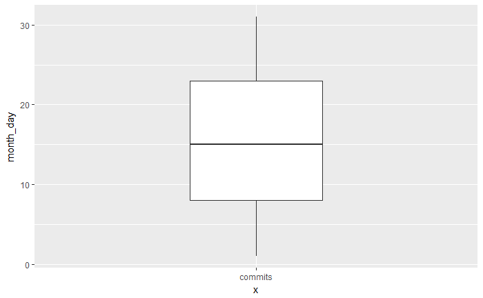

```r
python_github %>%
    ggplot(aes(y = month_day, x = "commits")) +
    geom_boxplot(width = .3)
```

### 2.3 the_month

Mês (numérico) em que o commit foi realizado.

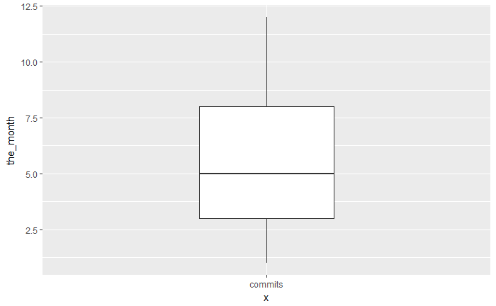

```r
python_github %>%
    ggplot(aes(y = the_month, x = "commits")) +
    geom_boxplot(width = .3)
```

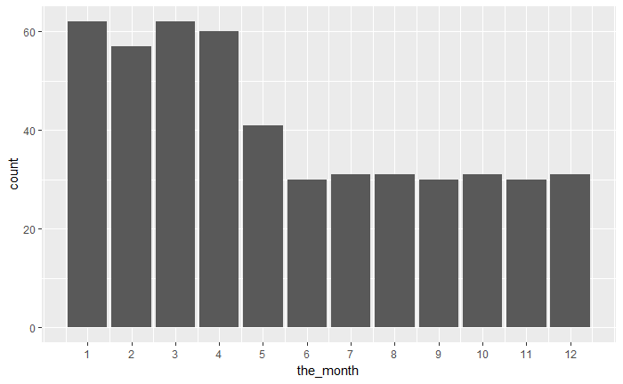

```r
python_github %>%
    ggplot(aes(x = the_month)) +
    geom_bar() +
    scale_x_continuous(breaks=c(1,2,3,4,5,6,7,8,9,10,11,12))
```

### 2.4 the_year

Ano (numérico) em que o commit foi realizado.

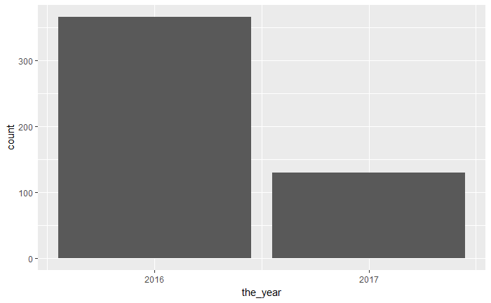

```r
python_github %>%
    ggplot(aes(x = the_year)) +
    geom_bar() +
    scale_x_continuous(breaks=c(2016, 2017))
```

### 2.5 users

Número de usuário que realizaram commit numa determinada data para uma linguagem de programação. Também conhecido nessa análise como métrica para popularidade ou produtividade.

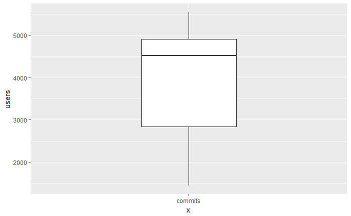

```r
python_github %>%
    ggplot(aes(y = users, x = "commits")) +
    geom_boxplot(width = .3)
```

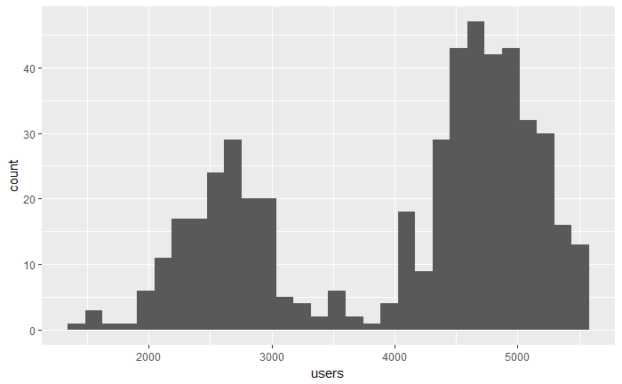

```r
python_github %>%
    ggplot(aes(x = users)) +
    geom_histogram(bins = 30)
```

## 3. Revisitando à pergunta

**Pergunta:** Existe uma diferença significativa nos números de edições em arquivos de extensão .py (Python) considerando o 1º semestre e o 2º semestre de um ano?

Em nossa análise, queremos descobrir em qual semestre do ano os desenvolvedores são mais produtivos. Para responder tal pergunta, precisamos comparar a média de commits para os dois semestres do ano, e avaliar se essa diferença entre as médias é significativa. Dessa forma, poderemos decidir em qual semestre do ano os desenvolvedores são mais produtivos.

### 3.1 Médias

```r
medias1x2 = python_github %>%
  group_by(semester) %>%
  summarise(media = mean(users))
medias1x2
```

| semester | media |
| --- | --- |
| 1º semestre | 4164.667 |
| 2º semestre | 3834.174 |

```r
diff.media.observada.1x2 = diff(medias1x2$media)
```

### 3.2 Intervalos de confiança

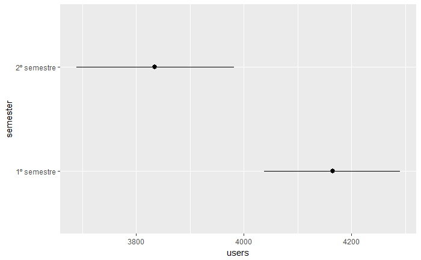

```r
ggplot(python_github, aes(y = users, x = semester)) +
  stat_summary(fun.data = "mean_cl_boot") +
  coord_flip()
```

### 3.3 Teste de hipótese com permutação

- **Hipótese nula:** Não existe diferença significativa no número de edições em arquivos de extensão .py comparando o 1º e semestre e o 2º semestre de um ano.
- **Hipótese alternativa:** Existe diferença significativa no número de edições em arquivos de extensão .py comparando o 1º semestre e o 2º semestre de um ano.

Desejamos que a hipótese nula seja refutada, para que isso aconteça, a diferença entre as médias de commits do 1º e 2º semestre deve ser significativa.

Realizamos a permutação de forma aleatória entre todos os registros de commits diários para os arquivos de extensão .py (Python). Para cada interação, permutamos os registros pelo semestre, e mantivemos fixo a quantidade de edições, dessa forma, obtivemos como resultado várias médias aleatórias. Realizamos esse processo 10.000 vezes e plotamos um histograma com todas as médias obtidas de forma aleatória pela permutação e a médias antes de permutar os valores.

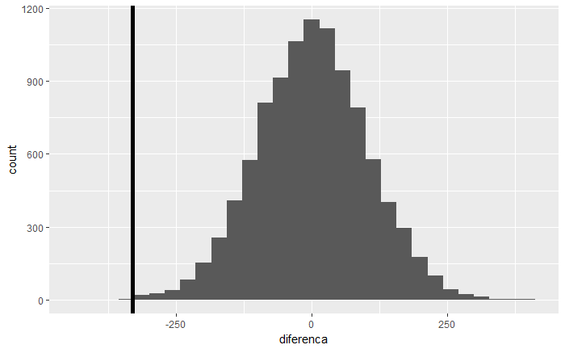

```r
set.seed(1)
diffs = replicate(10000, {
  medias = python_github %>%
    mutate(id_embaralhado = sample(semester, n())) %>%
    group_by(id_embaralhado) %>%
    summarise(media = mean(users))
  e1 = medias %>%
    filter(id_embaralhado == "1º semestre")
  e4 = medias %>%
    filter(id_embaralhado == "2º semestre")
  return(e1$media - e4$media)
})
tibble(diferenca = diffs) %>%
  ggplot(aes(x = diferenca)) +
  geom_histogram(bins = 30) +
  geom_vline(xintercept = diff.media.observada.1x2, size = 2)
```

De acordo com o gráfico, a diferença entre as médias está distante do valor zero. Para que a hipótese nula fosse reforçada, seria necessário que a linha da diferença entre as médias estivesse mais próxima do zero. Portanto, calculamos o p-value assumindo um nível de significância de 5% para nos certificar de que podemos rejeitar a hipótese nula.

```r
permutationTest2(python_github, mean(users), treatment = semester)
```

```
Call:
permutationTest2(data = python_github, statistic = mean(users),
    treatment = semester)
Replications: 9999
Two samples, sample sizes are 312 184

Summary Statistics for the difference between samples 1 and 2:
                                     Observed      Mean Alternative PValue
mean(users): 1º semestre-2º semestre 330.4928 -1.674154   two.sided  2e-04
```

Finalmente, podemos afirmar que existe uma diferença significativa no número de commits em arquivos de extensão .py, comparando o 1º e o 2º semestre de um ano.

## Vantagens e desvantagens

Neste trabalho utilizamos intervalos de confiança e p-value para fazer conclusões sobre nossa pergunta de pesquisa. Ambos os métodos nos permitem chegar a mesma conclusão, porém de formas diferentes.

O p-value se mostrou ser mais objetivo e mais simples para tirar conclusões. No entanto, a atribuição do valor da significância parece ser um “chute”, ou seja, não há muitas explicações para o fato do valor de 5% ser melhor aceito pela academia.

O intervalo de confiança, apesar de ser mais trabalhoso, nos permite tirar conclusões visualmente mais concretas. Isso acontece pelo simples fato de ICs evidenciarem os extremos e possibilitarem analisar as diferenças entre eles.

## Conclusão

Nesse estudo, analisamos os números de commits em arquivos de extensão .py para responder a seguinte questão: **Existe uma diferença significativa nos números de edições em arquivos de extensão .py (Python) considerando o 1º semestre e o 2º semestre de um ano?**